# Cover-weighted traits data setup

Knit on

November 14, 2026

# 1 Setup

```r
library(conflicted)
library(readxl)
library(mice)
library(ggmice)
library(tidyverse)
library(patchwork)
library(DT)

conflicts_prefer(dplyr::filter,
                 stats::lag)

options(digits = 3)

set.seed(2058)

theme_set(theme_minimal())

weat <- readRDS("intermediate/weat.rds")
dates <- readRDS("intermediate/dates.rds")

show <- vars(!c(lprior, lp__, b_Intercept))
```

## 1.1 Matrix product backend

Despite setting a seed, imputations with `mice()` from different machines or operating systems might differ slightly, while imputations from the same machine and OS should be fully reproducible. I narrowed this down to different matrix product implementations. To circumvent this problem, the following line sets NETLIB as default matrix backend (default on Windows) if available. Alternatively, use the provided `cwm_itp.rds` file in notebooks following this one.

```r
if (.Platform$OS.type == "unix"){
  library(flexiblas)
  if(flexiblas_avail() && "NETLIB" %in% flexiblas_list()){
    flexiblas_switch(flexiblas_load_backend("NETLIB"))
  }
  flexiblas_current_backend()
}
```

```
[1] "NETLIB"
```

## 1.2 Import trait data

```r
traits <- read_xlsx("Data/traits.xlsx", sheet = 1) |>
  select(species:persistence, la:sm, Fern_Sapro) |>
  #remove height if higher than recorded
  mutate(ph = if_else(ph < 1.5, ph, NA))

datatable(traits)
```

|  | species | BBRsize | offspring | spread | persistence | la | ln | ph | sla | ssd | sm | Fern_Sapro |
| --- | --- | --- | --- | --- | --- | --- | --- | --- | --- | --- | --- | --- |
| 1 | Adoxa_moschatellina | 10 | 4 | 13 | 1.6 | 1807.64 | 37.2424489 | 0.084653746 | 38.2413854675903 | 0.163855375 | 32.315 |  |
| 2 | Agrostis_tenuis | 18.9 | 2.7 | 7.7 | 3.6 | 167.15 | 22.56129771 | 0.26707069 | 28.1316400754013 | 0.238945838 | 0.0593 |  |
| 3 | Anemone_apennina | 15 | 1.8 | 1.88125 | 4 | 496 | 29.35457937 | 0.183014819 | 50.44067797 | 0.1885 | 2.3673 |  |
| 4 | Anemone_nemorosa | 15 | 1.8 | 1.88125 | 4 | 496 | 29.35457937 | 0.183014819 | 50.44067797 | 0.1885 | 2.3673 |  |
| 5 | Anthriscus_sylvestris | 12.9 | 1 | 0.5 | 3.2 | 4767.27689716312 | 27.96636393 | 0.83592049 | 30.5354821699739 | 0.205004764 | 4.1188 |  |
| 6 | Arisarum_proboscideum | 5 | 1 | 0.5 | 1 | 1477.96 | 26.8 | 0.104 | 29.295 |  |  |  |
| 7 | Arum_maculatum | 10.8 | 1 | 0.5 | 1.2 | 9170.61 | 42.30957338 | 0.233156255 | 32.9492416727746 | 0.103244576 | 34.9566 |  |
| 8 | Athyrium_filix-foemina | 20 | 0.5 | 0.5 | 4 | 15575.5 | 24.49 | 0.633536272 | 56.92239 | 0.3 | 3.68e-05 | F |
| 9 | Ballota_nigra | 10 | 0 | 0 | 0 | 717 | 23.7 | 0.600283566 | 20.265316461586 | 0.21115 | 0.8811 |  |
| 10 | Cardamine_bulbifera | 17 | 0.5 | 2.685 | 3.2 | 2676.888889 | 36.07396518 | 0.425017513 | 40.7350696566667 | 0.171804814 | 2.7 |  |

[output cut: 72 more lines]

## 1.3 Import vegetation data

```r
data <- read_csv("Data/abundances.csv", trim_ws = T) |>
  #remove bryophythes
  filter(!species %in% c("Atrichum_undulatum", "Hypnum_cupressiforme",
  "Plagiomnium_affine", "Polytrichum_formosum", "Rhizomnium_punctatum")) |>
  #use more correct names for the plots
  mutate(plot = recode_values(plot,
                              "ABR01" ~ "01-ABR1",
                              "CAL03" ~ "03-CAL1",
                              "CAM04" ~ "04-CAM1",
                              "VEN20" ~ "20-VEN1",
                              default = plot)) |>
  #sum covers inside subplots
  group_by(date, plot, species) |>
  summarise(cover = sum(cover)) |>
  #convert to proportions
  mutate(cover = cover/sum(cover)) |>
  ungroup()
```

## 1.4 Filter plots with missing trait data

Ferns and saprophytes are excluded for some traits: ferns for diaspore mass, saprophytes for height and leaf traits.

```r
# leaf traits and height (competition for light) to exclude saprophytes
leaf_height <- c("la", "ln", "sla", "ph")

#tibble to store vegetation, weather data, and models for each trait
cwm <- tibble(trait = traits |>
                select(!c(species, Fern_Sapro)) |>
                colnames())

#total number of plot-years, same for all traits
plotn <- data |>
  summarise(n_distinct(date, plot)) |>
  pull()

#function to filter data for each trait based on cover
traitfilter <- function(trait){
  subtrait <- traits |>
    select(species, Fern_Sapro, trait = {{trait}}) |>
    drop_na(trait)

  subtrait <- if(trait == "sm"){
    #exclude ferns for seed mass
    subtrait |>
      filter_out(Fern_Sapro == "F")
  } else if(trait %in% leaf_height){
    #exclude saprophytes for leaf and height traits
    subtrait |>
      filter_out(Fern_Sapro == "Sapro")
  } else subtrait

  data |>
    filter(species %in% subtrait$species) |>
    group_by(date, plot) |>
    mutate(tot_cover = sum(cover)) |>
    filter(tot_cover > 0.8) |>
    select(!tot_cover) |>
    #restore sums to 1
    mutate(cover = cover / sum(cover)) |>
    ungroup()
}

cwm <- cwm |>
  mutate(d = map(trait, traitfilter),
         n_left = map_int(d, \(x) x |>
                        summarise(n_distinct(date, plot)) |>
                        pull()),
         n_removed = plotn - n_left)

datatable(cwm)
```

|  | trait | d | n_left | n_removed |
| --- | --- | --- | --- | --- |
| 1 | BBRsize | {'date': [1999, 1999, 1999, 1999, 1999, 1999, 1999, 1999, 1999, 1999, 1999, 1999, 1999, 1999, 1999, 1999, 1999, 1999, 1999, 1999, 1999, 1999, 1999, 1999, 1999, 1999, 1999, 1999, 1999, 1999, 1999, 1999… | 32 | 0 |
| 2 | offspring | {'date': [1999, 1999, 1999, 1999, 1999, 1999, 1999, 1999, 1999, 1999, 1999, 1999, 1999, 1999, 1999, 1999, 1999, 1999, 1999, 1999, 1999, 1999, 1999, 1999, 1999, 1999, 1999, 1999, 1999, 1999, 1999, 1999… | 32 | 0 |
| 3 | spread | {'date': [1999, 1999, 1999, 1999, 1999, 1999, 1999, 1999, 1999, 1999, 1999, 1999, 1999, 1999, 1999, 1999, 1999, 1999, 1999, 1999, 1999, 1999, 1999, 1999, 1999, 1999, 1999, 1999, 1999, 1999, 1999, 1999… | 32 | 0 |
| 4 | persistence | {'date': [1999, 1999, 1999, 1999, 1999, 1999, 1999, 1999, 1999, 1999, 1999, 1999, 1999, 1999, 1999, 1999, 1999, 1999, 1999, 1999, 1999, 1999, 1999, 1999, 1999, 1999, 1999, 1999, 1999, 1999, 1999, 1999… | 32 | 0 |
| 5 | la | {'date': [1999, 1999, 1999, 1999, 1999, 1999, 1999, 1999, 1999, 1999, 1999, 1999, 1999, 1999, 1999, 1999, 1999, 1999, 1999, 1999, 1999, 1999, 1999, 1999, 1999, 1999, 1999, 1999, 1999, 1999, 1999, 1999… | 31 | 1 |
| 6 | ln | {'date': [1999, 1999, 1999, 1999, 1999, 1999, 1999, 1999, 1999, 1999, 1999, 1999, 1999, 1999, 1999, 1999, 1999, 1999, 1999, 1999, 1999, 1999, 1999, 1999, 1999, 1999, 1999, 1999, 1999, 1999, 1999, 1999… | 25 | 7 |
| 7 | ph | {'date': [1999, 1999, 1999, 1999, 1999, 1999, 1999, 1999, 1999, 1999, 1999, 1999, 1999, 1999, 1999, 1999, 1999, 1999, 1999, 1999, 1999, 1999, 1999, 1999, 1999, 1999, 1999, 1999, 1999, 1999, 1999, 1999… | 32 | 0 |
| 8 | sla | {'date': [1999, 1999, 1999, 1999, 1999, 1999, 1999, 1999, 1999, 1999, 1999, 1999, 1999, 1999, 1999, 1999, 1999, 1999, 1999, 1999, 1999, 1999, 1999, 1999, 1999, 1999, 1999, 1999, 1999, 1999, 1999, 1999… | 31 | 1 |
| 9 | ssd | {'date': [1999, 1999, 1999, 1999, 1999, 1999, 1999, 1999, 1999, 1999, 1999, 1999, 1999, 1999, 1999, 1999, 1999, 1999, 1999, 1999, 1999, 1999, 1999, 1999, 1999, 1999, 1999, 1999, 1999, 1999, 1999, 1999… | 24 | 8 |
| 10 | sm | {'date': [1999, 1999, 1999, 1999, 1999, 1999, 1999, 1999, 1999, 1999, 1999, 1999, 1999, 1999, 1999, 1999, 1999, 1999, 1999, 1999, 1999, 1999, 1999, 1999, 1999, 1999, 1999, 1999, 1999, 1999, 1999, 1999… | 28 | 4 |

Which site-years have been removed?

```r
cwm |>
  mutate(removed = map(d,
                       \(x) anti_join(data |>
                                        distinct(date, plot),
                                      x))) |>
  select(trait, removed) |>
  unnest(removed) |>
  datatable()
```

|  | trait | date | plot |
| --- | --- | --- | --- |
| 1 | la | 2008 | 04-CAM1 |
| 2 | ln | 1999 | 20-VEN1 |
| 3 | ln | 2000 | 20-VEN1 |
| 4 | ln | 2001 | 20-VEN1 |
| 5 | ln | 2002 | 20-VEN1 |
| 6 | ln | 2008 | 04-CAM1 |
| 7 | ln | 2008 | 20-VEN1 |
| 8 | ln | 2011 | 20-VEN1 |
| 9 | sla | 2008 | 04-CAM1 |
| 10 | ssd | 1999 | 20-VEN1 |

[output cut: 11 more lines]

## 1.5 Empirical CWM

```r
#calculate empirical CWM as outcome for imputation
calc_cwm <- function(x, trait){
  traits |>
    select(species, all_of(trait)) |>
    right_join(x) |>
    summarise(cwm = weighted.mean(.data[[trait]], cover, na.rm = T),
              .by = c(date, plot)) |>
    rename(survey_year = date, site = plot)
}

cwm <- cwm |>
  mutate(imp = map2(d, trait, calc_cwm))
```

Plot yearly trends in CWM:

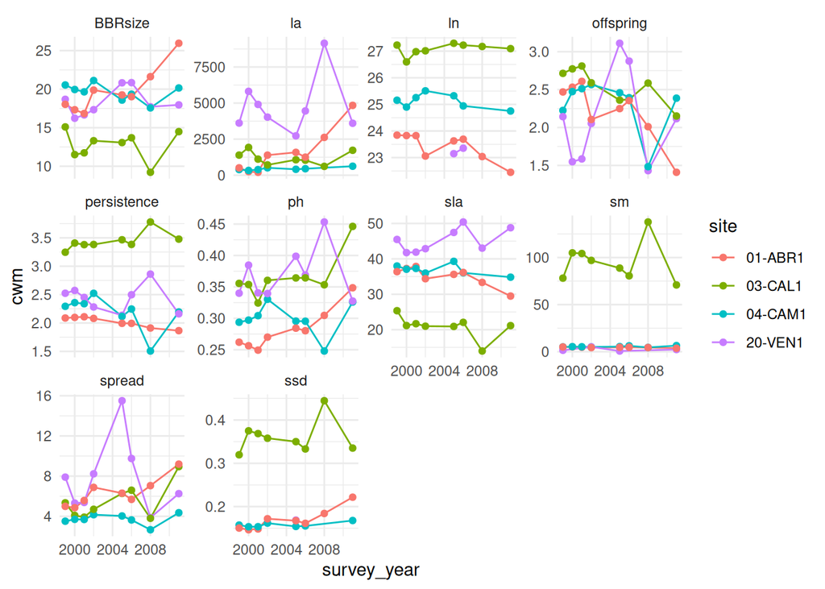

```r
cwm |>
  select(trait, imp) |>
  unnest(imp) |>
  ggplot(aes(x = survey_year, y = cwm, colour = site)) +
  geom_line() +
  geom_point() +
  facet_wrap(vars(trait), scales = "free_y")
```

The large increase in leaf area in 01-ABR1 seems driven by *Rubus caesius*

```r
cwm |>
  filter(trait == "la") |>
  pluck("d", 1) |>
  filter(plot == "01-ABR1") |>
  arrange(desc(cover)) |>
  left_join(traits |>  select(species, la)) |>
  datatable()
```

|  | date | plot | species | cover | la |
| --- | --- | --- | --- | --- | --- |
| 1 | 2000 | 01-ABR1 | Galium_odoratum | 0.8498327759197324 | 84.4238013492063 |
| 2 | 1999 | 01-ABR1 | Galium_odoratum | 0.8178819444444444 | 84.4238013492063 |
| 3 | 2001 | 01-ABR1 | Galium_odoratum | 0.7880168963983992 | 84.4238013492063 |
| 4 | 2006 | 01-ABR1 | Galium_odoratum | 0.7225188442211056 | 84.4238013492063 |
| 5 | 2005 | 01-ABR1 | Galium_odoratum | 0.6651569071497897 | 84.4238013492063 |
| 6 | 2002 | 01-ABR1 | Galium_odoratum | 0.6440611524892199 | 84.4238013492063 |
| 7 | 2011 | 01-ABR1 | Rubus_caesius | 0.599396291504959 | 7668.0175 |
| 8 | 2008 | 01-ABR1 | Galium_odoratum | 0.5638520586182834 | 84.4238013492063 |
| 9 | 2008 | 01-ABR1 | Rubus_caesius | 0.3183879972086532 | 7668.0175 |
| 10 | 2011 | 01-ABR1 | Galium_odoratum | 0.2708063820612333 | 84.4238013492063 |

[output cut: 73 more lines]

The consistently higher seed mass and SSD in 03-CAL1 seems to be because of *Ruscus aculeatus*

```r
cwm |>
  filter(trait == "sm") |>
  pluck("d", 1) |>
  filter(plot == "03-CAL1") |>
  arrange(desc(cover)) |>
  left_join(traits |>  select(species, sm)) |>
  datatable()
```

|  | date | plot | species | cover | sm |
| --- | --- | --- | --- | --- | --- |
| 1 | 2008 | 03-CAL1 | Ruscus_aculeatus | 0.726252692703943 | 187.2912 |
| 2 | 2000 | 03-CAL1 | Ruscus_aculeatus | 0.5517007222668066 | 187.2912 |
| 3 | 2001 | 03-CAL1 | Ruscus_aculeatus | 0.5473911146472293 | 187.2912 |
| 4 | 2002 | 03-CAL1 | Ruscus_aculeatus | 0.50422544474039 | 187.2912 |
| 5 | 2005 | 03-CAL1 | Ruscus_aculeatus | 0.4589422498758202 | 187.2912 |
| 6 | 2006 | 03-CAL1 | Ruscus_aculeatus | 0.4140777475603903 | 187.2912 |
| 7 | 1999 | 03-CAL1 | Ruscus_aculeatus | 0.4046904065904863 | 187.2912 |
| 8 | 2011 | 03-CAL1 | Ruscus_aculeatus | 0.3607341847868228 | 187.2912 |
| 9 | 2011 | 03-CAL1 | Vinca_minor | 0.2273114968375112 | 6.13 |
| 10 | 2006 | 03-CAL1 | Vinca_minor | 0.1996373913507172 | 6.13 |

[output cut: 154 more lines]

```r
cwm |>
  filter(trait == "ssd") |>
  pluck("d", 1) |>
  filter(plot == "03-CAL1") |>
  arrange(desc(cover)) |>
  left_join(traits |>  select(species, ssd)) |>
  datatable()
```

|  | date | plot | species | cover | ssd |
| --- | --- | --- | --- | --- | --- |
| 1 | 2008 | 03-CAL1 | Ruscus_aculeatus | 0.7617092337917486 | 0.52 |
| 2 | 2000 | 03-CAL1 | Ruscus_aculeatus | 0.5712550736680623 | 0.52 |
| 3 | 2001 | 03-CAL1 | Ruscus_aculeatus | 0.5601428721504359 | 0.52 |
| 4 | 2002 | 03-CAL1 | Ruscus_aculeatus | 0.503563101375981 | 0.52 |
| 5 | 2005 | 03-CAL1 | Ruscus_aculeatus | 0.4965843033534645 | 0.52 |
| 6 | 2006 | 03-CAL1 | Ruscus_aculeatus | 0.4496091714434601 | 0.52 |
| 7 | 2011 | 03-CAL1 | Ruscus_aculeatus | 0.42679842208039 | 0.52 |
| 8 | 1999 | 03-CAL1 | Ruscus_aculeatus | 0.4007341815454654 | 0.52 |
| 9 | 2011 | 03-CAL1 | Vinca_minor | 0.2689409328597827 | 0.19543 |
| 10 | 2006 | 03-CAL1 | Vinca_minor | 0.2167679925887326 | 0.19543 |

[output cut: 155 more lines]

# 2 Imputation

Imputation needs to be done for each trait outcome to be congenial. The considerations about the imputation models and variables are the same as in the “weather” notebook.

```r
#remove min and max columns
weat <- weat |>
  select(!contains(c("min", "max"))) |>
#remove empty columns
  select(!c(solar_radiation_mean_ITP, wind_speed_mean_ITP)) |>
#remove wind speed
  select(!wind_speed_mean_OFD)

# identify variable blocks
temp_vars <- colnames(weat)[4:8]

hum_vars <- colnames(weat)[9:12]

#join dates
weat <- weat |>
  full_join(dates, relationship = "one-to-one")
```

```r
#add weather to data
cwm <- cwm |>
  mutate(imp = map(imp, \(x) weat |>
                     left_join(x)))

#remove surveys without any weather
cwm <- cwm |>
  mutate(exclude = map(imp, \(x) x |>
                     drop_na(survey_year) |>
                     group_by(site, survey_year) |>
                     summarise(across(air_t_mean_OFD:precipitation_ITP,
                                      \(x) sum(is.na(x))), .groups = "drop") |>
                     filter(if_all(air_t_mean_OFD:precipitation_ITP, \(x) x == 12)) |>
                     select(site, survey_year)))

cwm <- cwm |>
  mutate(imp = map2(imp, exclude, \(x, y) x |>
                      anti_join(y) |>
                      mutate(across(c(site, survey_year, year, month), as_factor)))) |>
  select(!exclude)
```

Setting up `mice`:

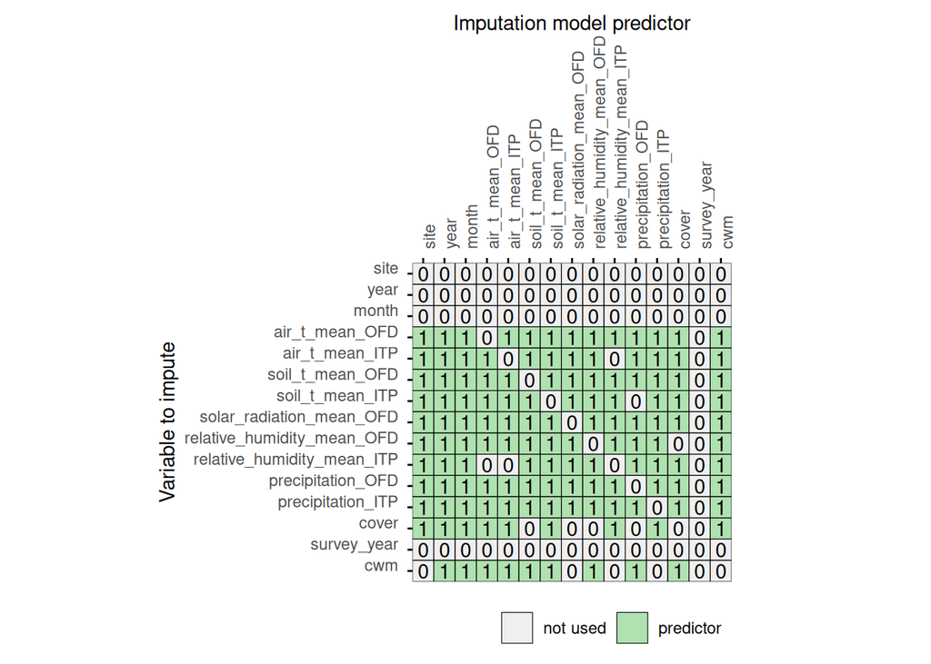

```r
method <- cwm |>
  pluck("imp", 1) |>
  make.method()

method["survey_year"] <- ""

predmat <- cwm |>
  pluck("imp", 1) |>
  quickpred(include = c("cwm", "month"), exclude = "survey_year")

#exclude outcomes which are not imputed for clarity
predmat[which(method == ""),] <- 0

plot_pred(predmat, rotate = T)
```

Imputation:

```r
cwm <- cwm |>
  mutate(mice = map(imp, \(x) x |>
                      mice(predictorMatrix = predmat,
                           method = method,
                           m = 5, maxit = 100,
                           printFlag = F,
                           seed = 19223)))

#complete and keep only data corresponding to surveys

cwm <- cwm |>
  mutate(complete = map(mice, \(x) x |>
                          complete(action = "long") |>
                          semi_join(dates |>
                                      mutate(across(everything(), as_factor)))))
```

## 2.1 Imputation diagnostics

Check for NAs, convergence, differences between imputations, imputed against observed data. Since there is heterogeneity in months, the latter is done by month.

```r
#plotting functions
#box plot
bwplot_imp <- function(data, vars) {
  map(vars,
      ~ {
        ggmice(data, aes(x = .imp, y = .data[[.x]])) +
          geom_boxplot() +
          labs(x = "Imputation number")
      }
  ) |>
    patchwork::wrap_plots()&
    theme(legend.position = "none")
}

#density plot
densplot_imp <- function(data, vars) {
  map(vars,
      ~ {
        ggmice(data, aes(x = .data[[.x]], group = .imp, size = .where)) +
          geom_density()+
          scale_size_manual(
            values = c("observed" = 1, "imputed" = 0.5),
            guide = "none")+
          facet_wrap(~month,
                     ncol = 3,
                     strip.position = "right",
                     scales = "free_y")+
          theme(strip.text = element_text(size = 8))+
          ggtitle("month")
      }
  ) |>
    patchwork::wrap_plots(guides = "collect", ncol = 1)&
    theme(legend.position = "bottom")
}

#convergence plot
convplot_imp <- function(data, vars, dia = psrf){
  convergence(data) |>
    filter_out(is.na({{dia}})) |>
    ggplot(aes(x = .it, y = {{dia}})) +
    geom_line() +
    geom_hline(yintercept = 1, linetype = 2, alpha = 0.5) +
    facet_wrap(~vrb)
}

# imputed variables
to_plot <- c("air_t_mean_ITP", "soil_t_mean_ITP", "relative_humidity_mean_ITP", "precipitation_ITP")

cwm |>
  mutate(nas = map(complete, \(t) t |>
                     summarise(across(everything(), \(x) sum(is.na(x))))), .keep = "none") |>
  unnest_wider(nas) |>
  filter(if_any(everything(), \(x) x > 0))
```

| site | year | month | air_t_mean_OFD | air_t_mean_ITP | soil_t_mean_OFD | soil_t_mean_ITP | solar_radiation_mean_OFD | relative_humidity_mean_OFD | relative_humidity_mean_ITP | precipitation_OFD | precipitation_ITP | cover | survey_year | cwm | .imp | .id |
| --- | --- | --- | --- | --- | --- | --- | --- | --- | --- | --- | --- | --- | --- | --- | --- | --- |

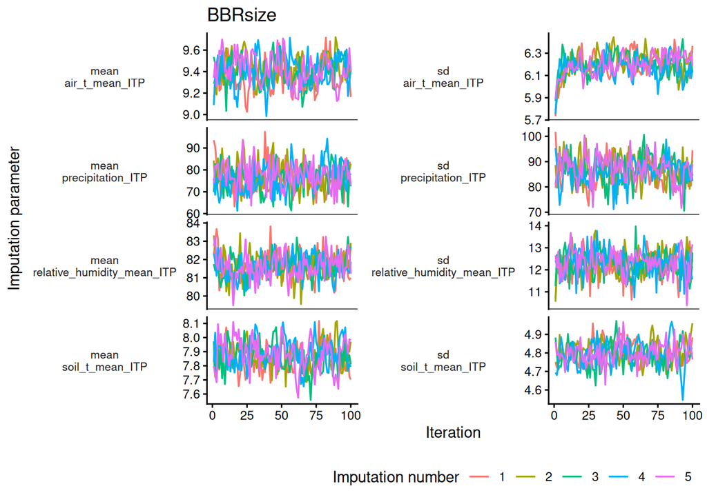

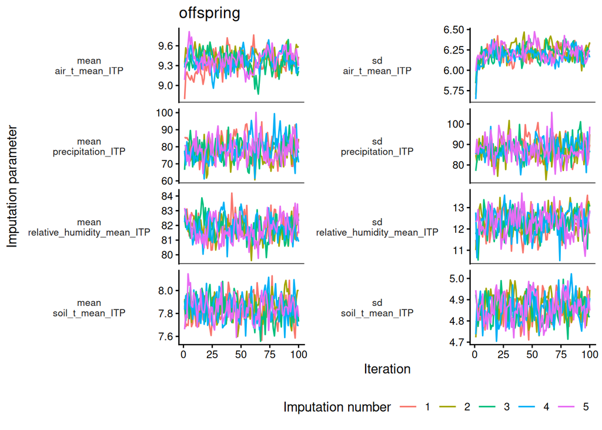

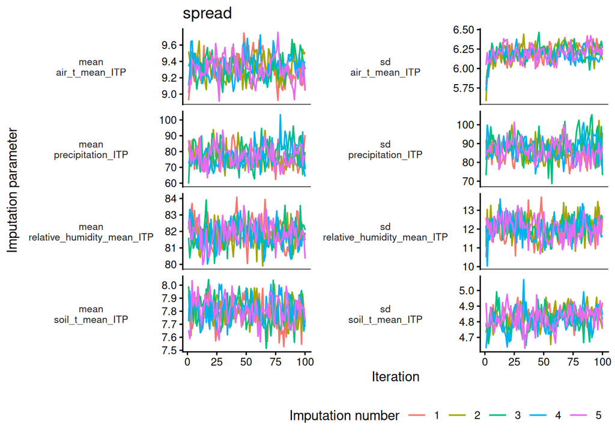

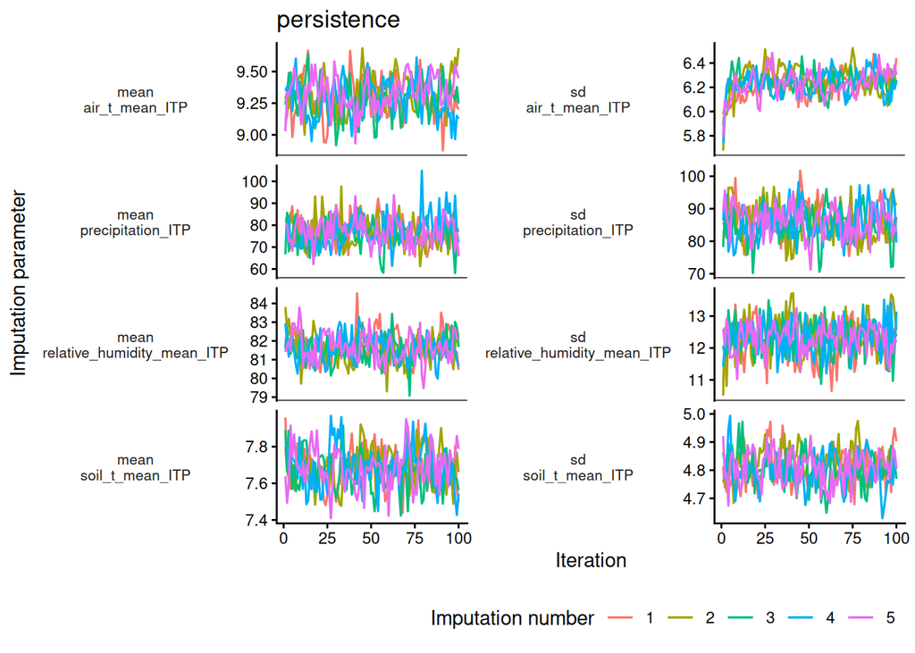

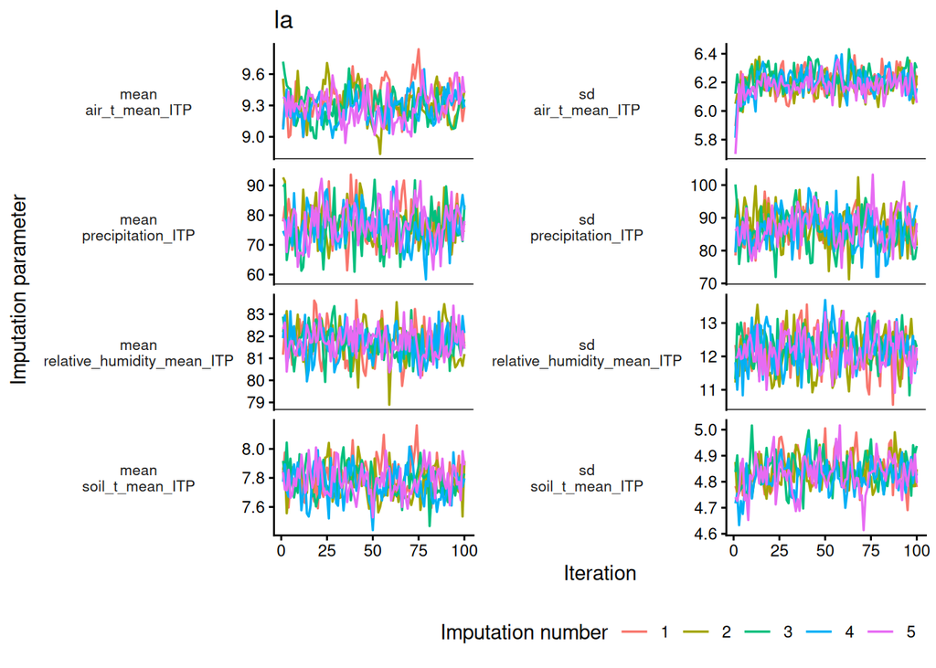

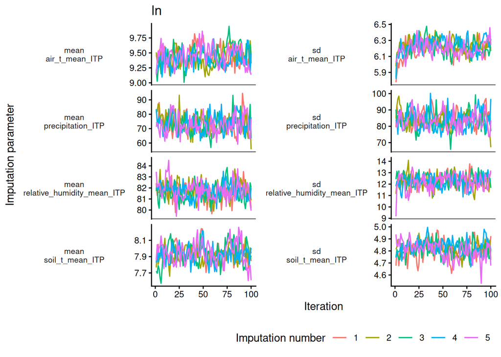

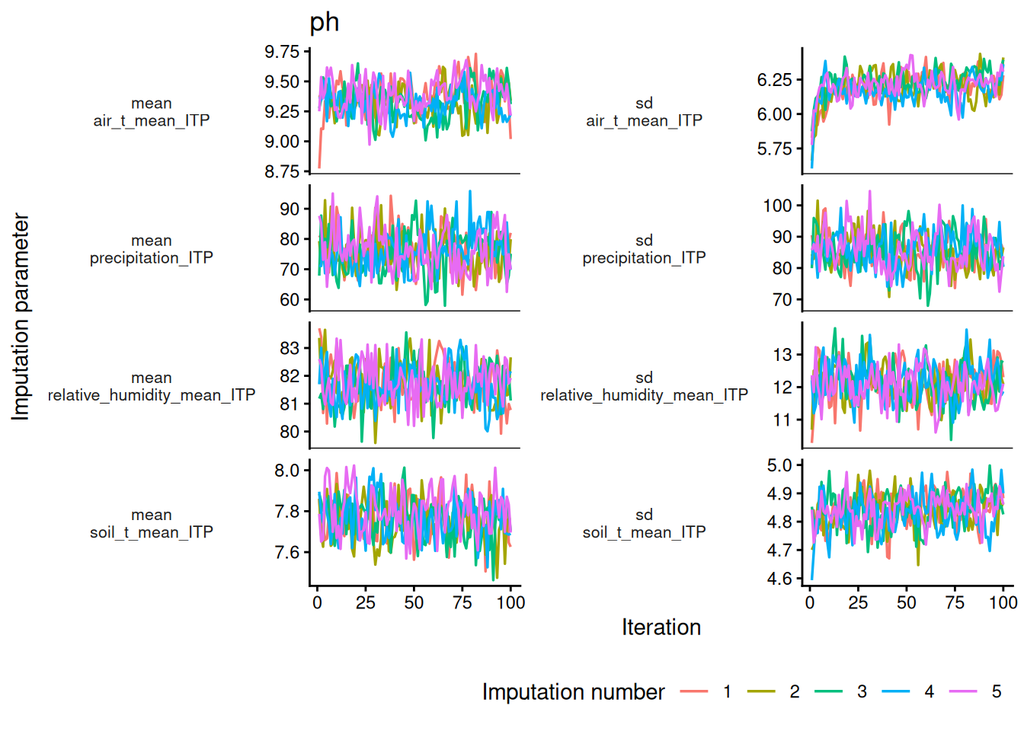

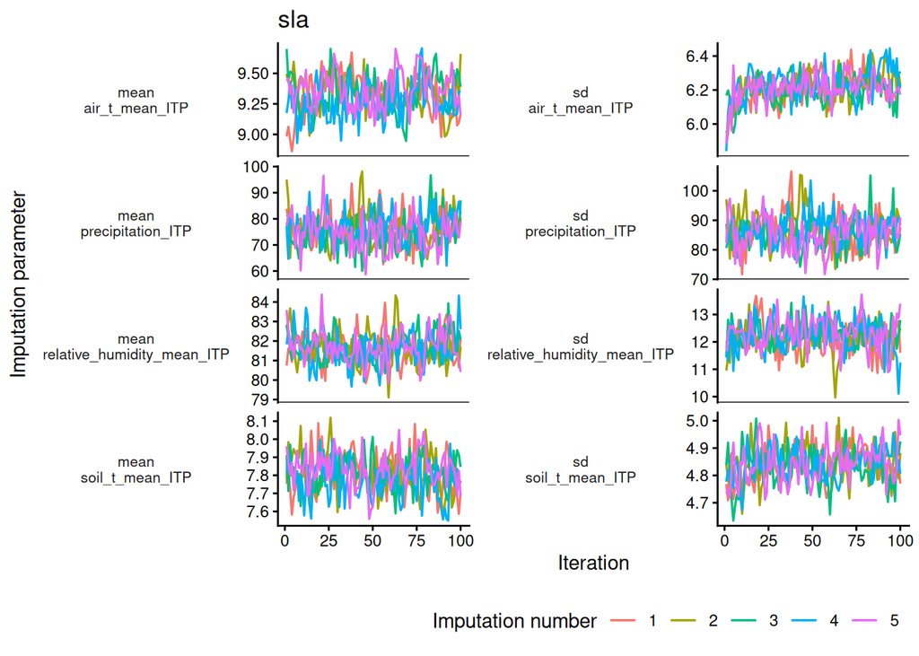

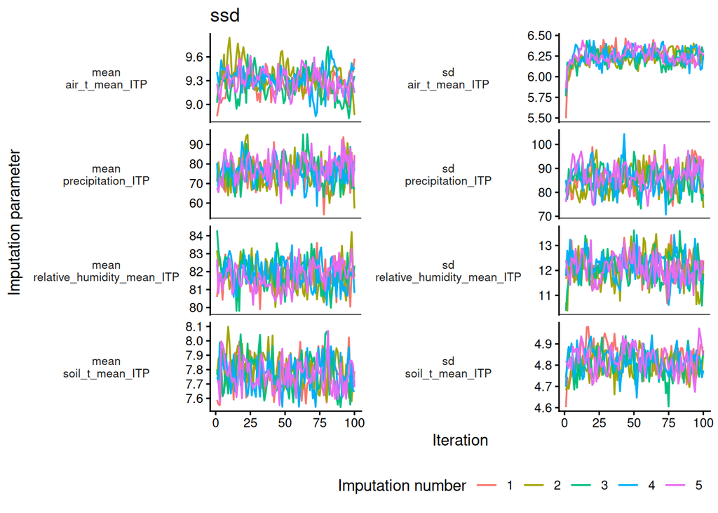

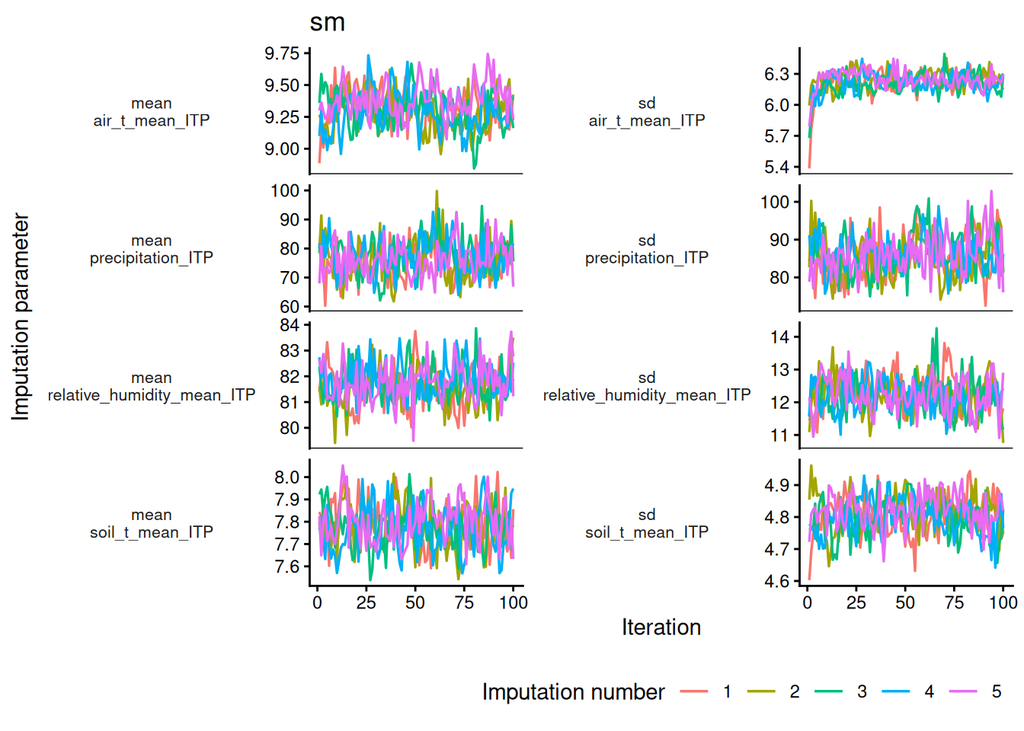

```r
map2(cwm$mice, cwm$trait, \(x, y) plot_trace(x, vrb = !!to_plot) +
              theme(strip.text.y.left = element_text(size = 8, angle = 0)) +
              labs(title = y))
```

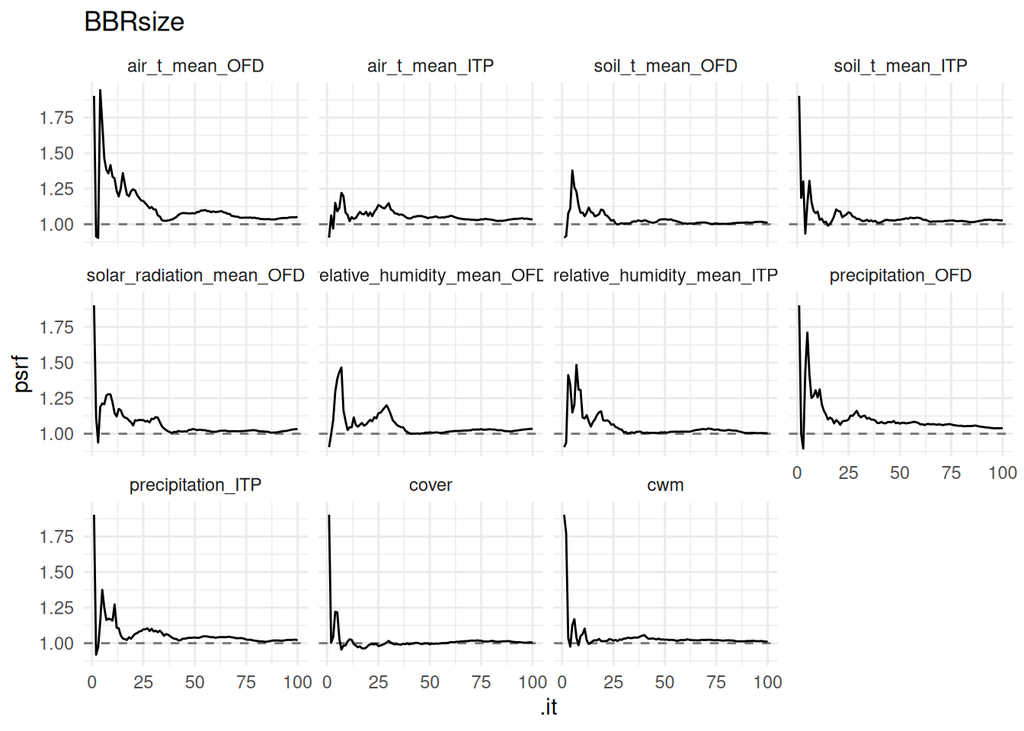

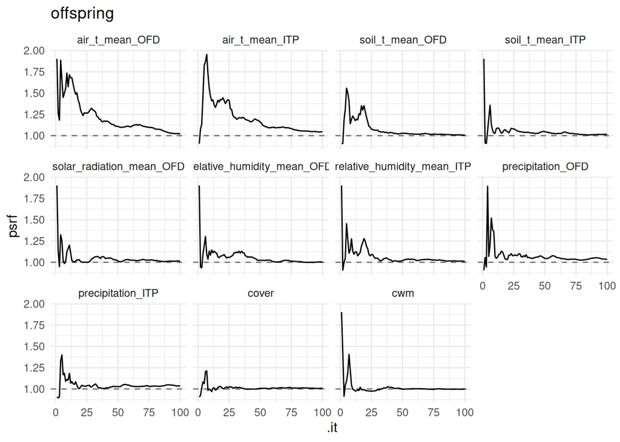

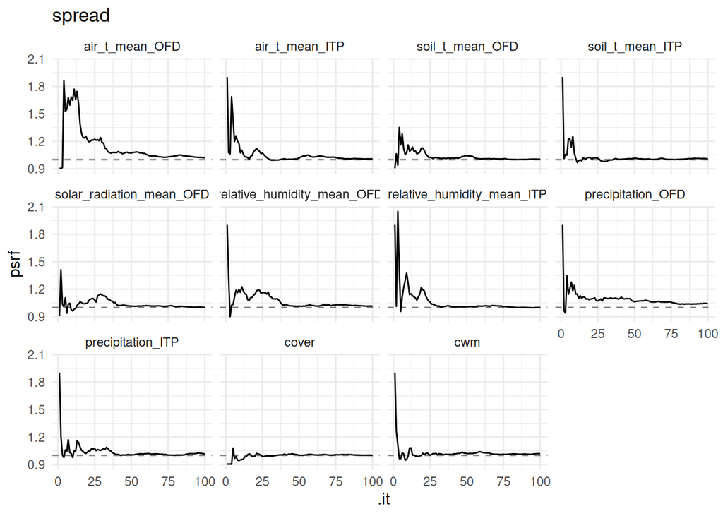

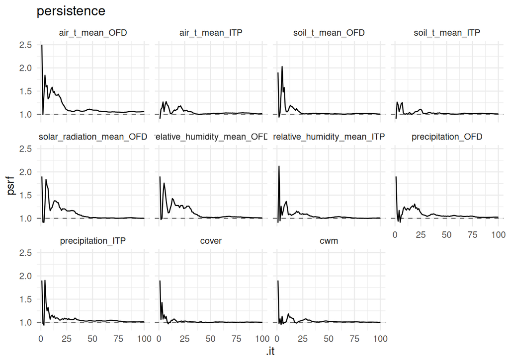

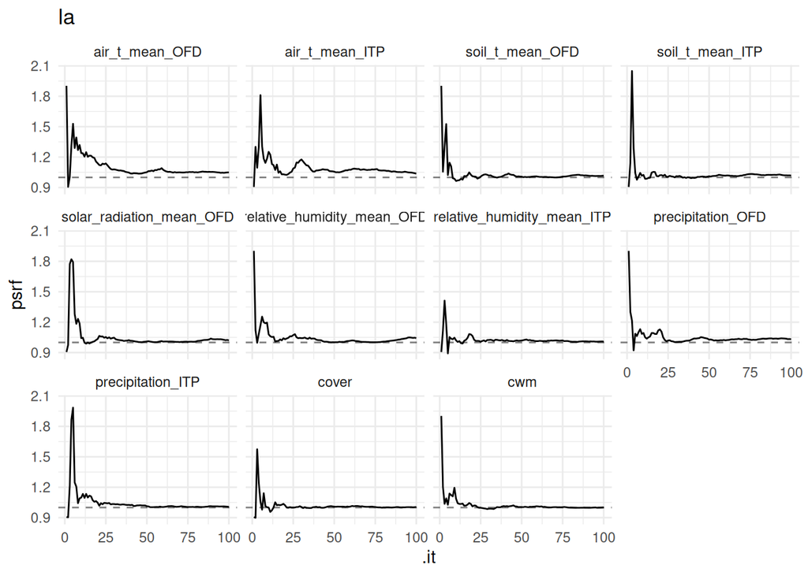

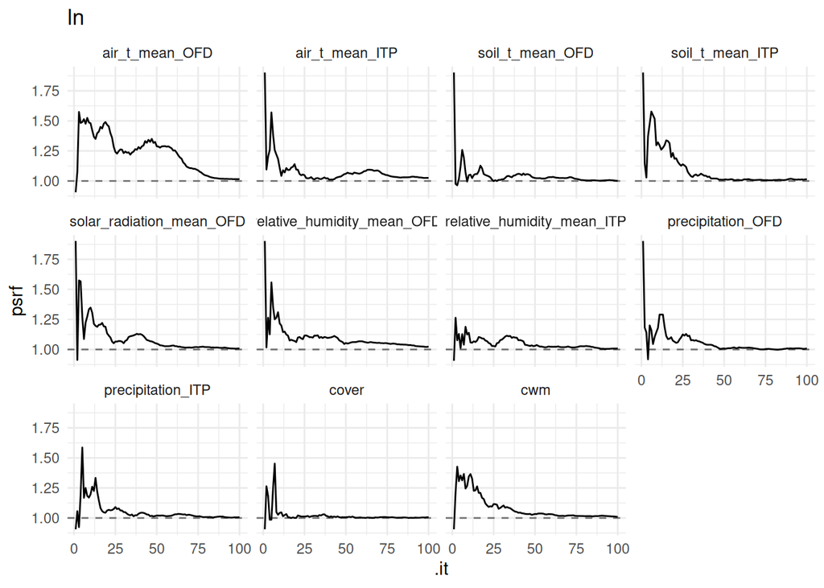

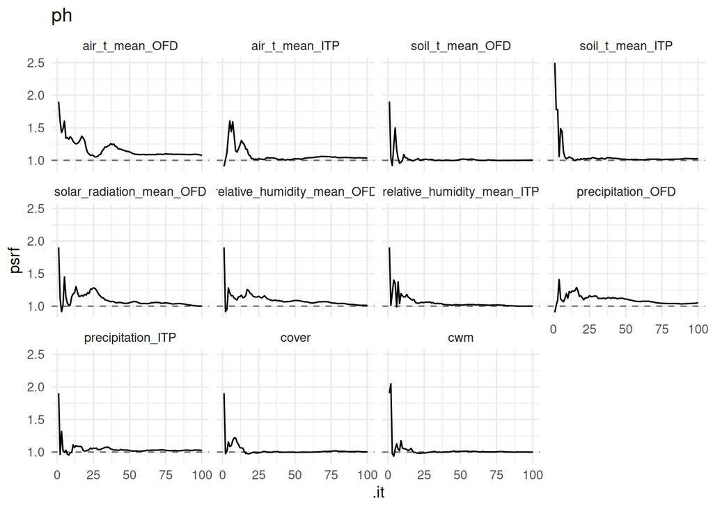

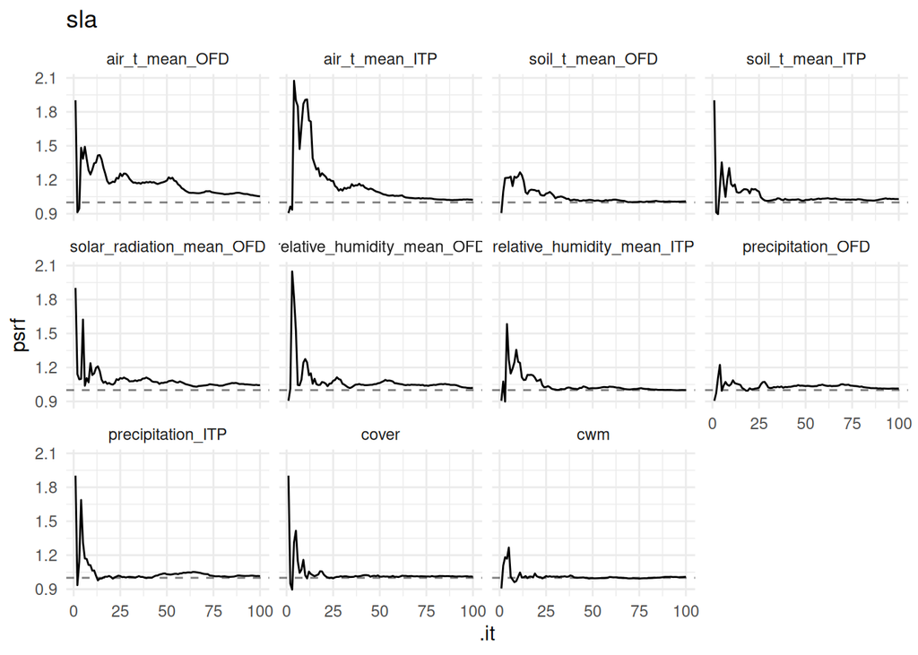

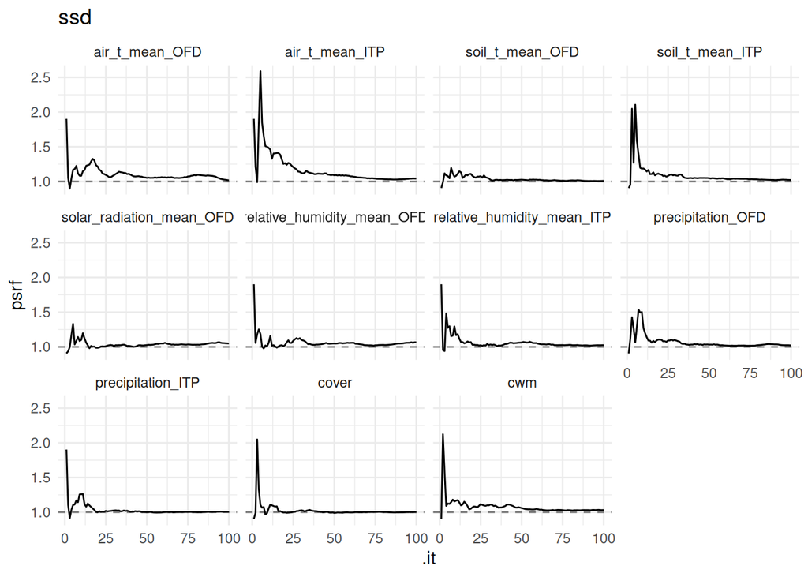

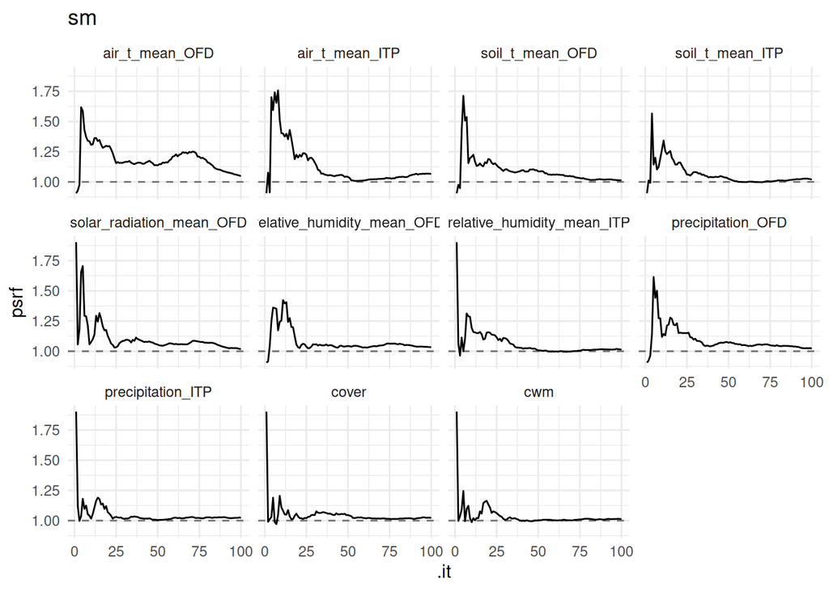

```r
map2(cwm$mice, cwm$trait, \(x, y) convplot_imp(x) +
        labs(title = y))
```

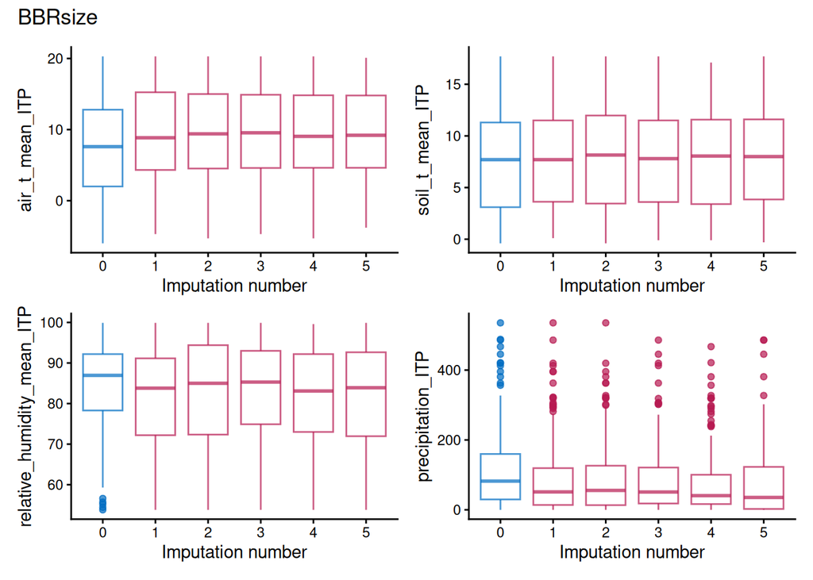

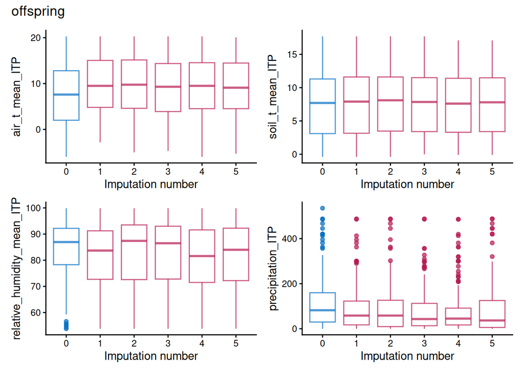

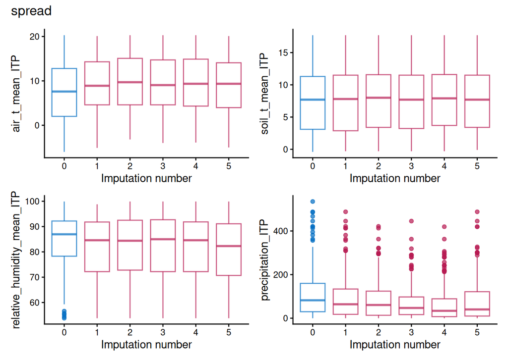

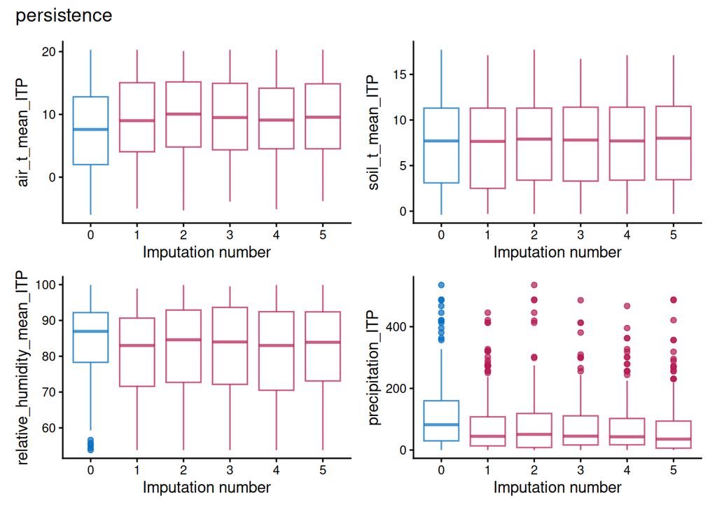

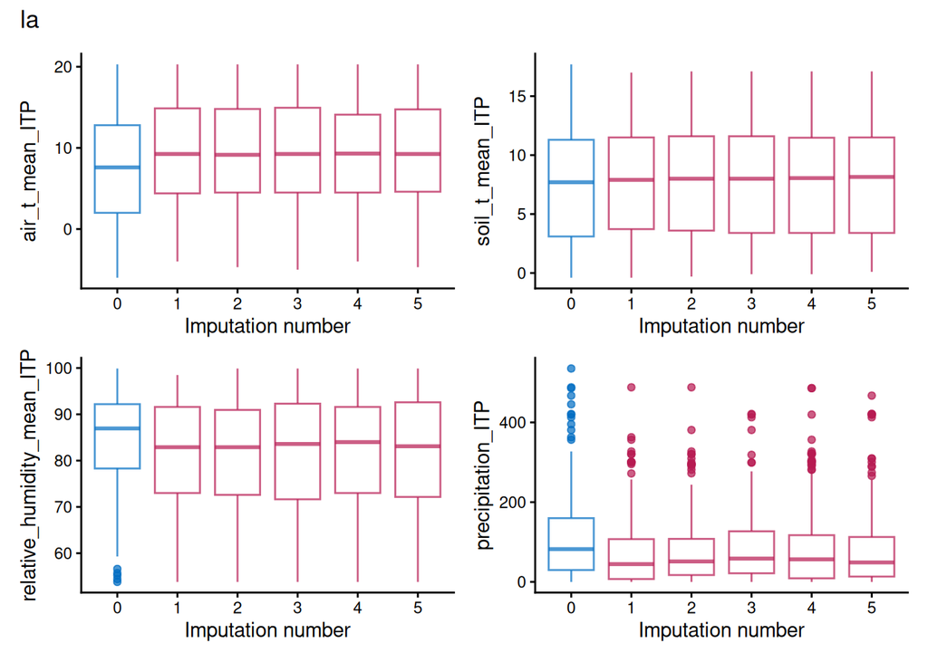

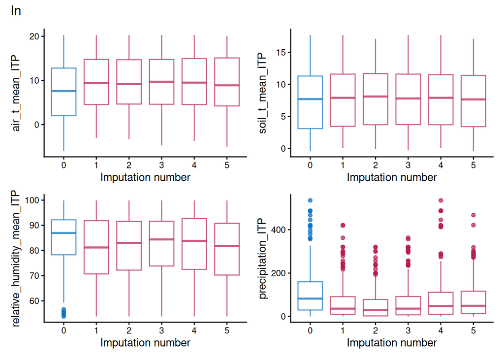

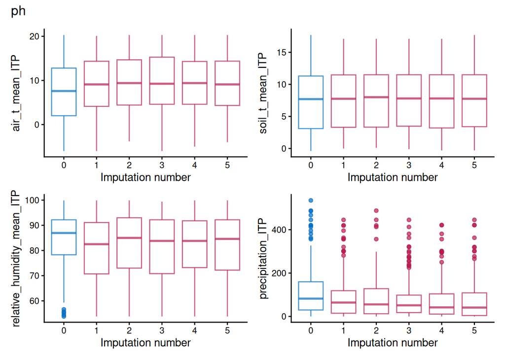

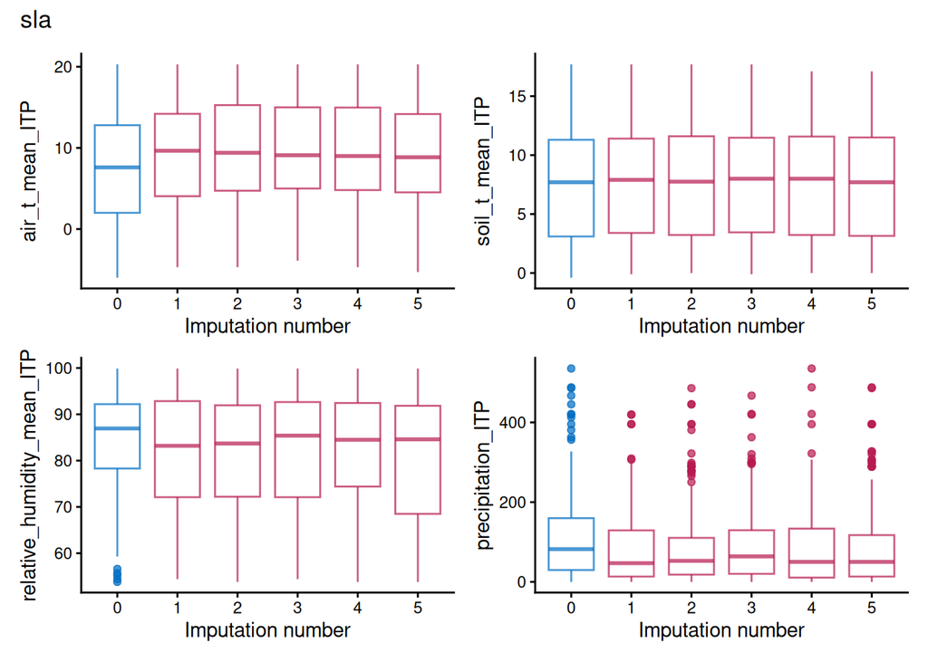

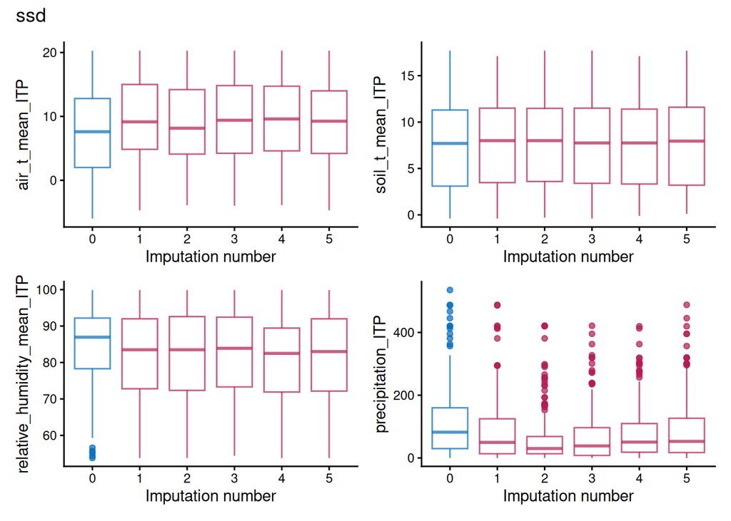

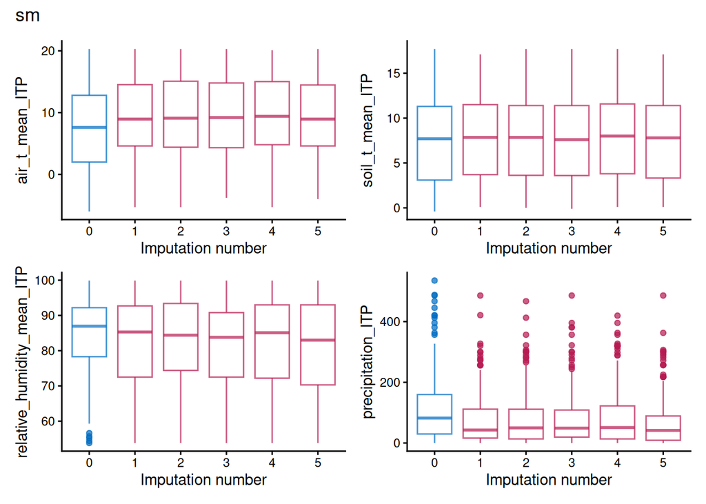

```r
map2(cwm$mice, cwm$trait, \(x, y) bwplot_imp(x, to_plot) &
       plot_annotation(title = y))
```